# Medicare at 65: Sharp RD Estimates

The effect of Medicare eligibility on healthcare use, with robustness checks

# 1 Specification

## 1.1 Estimand

We estimate the jump in healthcare use at age 65:

$$\tau_{RD}=\lim_{a\downarrow 65}E[Y_i\mid
Age_i=a]-\lim_{a\uparrow 65}E[Y_i\mid Age_i=a].$$

Treatment is **eligibility**, $1(Age_i\ge65)$, so under the identifying assumptions $\tau_{RD}$ is the local intention-to-treat effect of becoming eligible for Medicare for people near 65. It is not an enrolment effect. The main outcome is seeing a doctor in the past year (`sawdr`). An overnight hospital stay in the past year (`inhosp`) is secondary.

The fuzzy RD section divides this kind of outcome jump by the jump in Medicare coverage. That ratio is a local effect of enrolment for people who take up Medicare because they turn 65, under additional first-stage, exclusion and monotonicity assumptions. The ratio needs the same respondents in its numerator and denominator, so this report also shows the sharp jump on the fuzzy RD sample.

## 1.2 Estimator

Local linear regression within **5 years of 65**, with separate age slopes on each side and survey-year fixed effects. The specification is identical to the identification report; both use `rd_functions.R`.

$$Y_i=\alpha+\tau\,1(Age_i\ge65)+\beta(Age_i-65)+\delta\,1(Age_i\ge65)(Age_i-65)+\lambda_{year(i)}+\varepsilon_i,\qquad
|Age_i-65|<5.$$

Each observation is weighted by its NHIS survey weight times a triangular kernel:

$$w_i=\frac{wt_i}{\overline{wt}}\times\max\left\{0,\;1-\frac{|Age_i-65|}{h}\right\}.$$

The survey weight $wt_i$ is the weight supplied in the replication file, unchanged. Standard errors are heteroskedasticity-robust (HC1). 95% confidence intervals and p-values use normal critical values, as in the fuzzy RD section.

## 1.3 Sample

The data are NHIS 1992–1996 from the team’s cleaned file, built from the Card, Dobkin and Maestas replication file. Missing outcomes are kept in that file, so each outcome uses everyone with that outcome observed:

- **Doctor visits:** 34,972 respondents within 5 years of 65 (17,231 below and 17,741 at or above).
- **Hospital stays:** 35,513 respondents (17,496 below and 18,017 at or above).

The hospital sample is larger because it includes 541 respondents who answered the hospital question but not the doctor question. An earlier version required a doctor answer for both outcomes and dropped them. Neither main model requires Medicare coverage.

## 1.4 Identification evidence

The identification report finds no statistically significant covariate or response-rate discontinuities under its reported specifications. The employment jump at 65 is 0.81 pp (95% CI [-1.34, 2.95]; p = 0.46). The same test detects a -3.95 pp drop at 62 (p = 0.0452), where early Social Security claiming begins. The age-62 contrast shows sensitivity to that particular change, not equal power or absence of retirement changes at 65. Quarter-age coding may misclassify eligibility near the threshold, and both outcomes include the preceding 12 months. The donut and exposure checks below assess sensitivity to these features without resolving them completely.

# 2 Graphical evidence

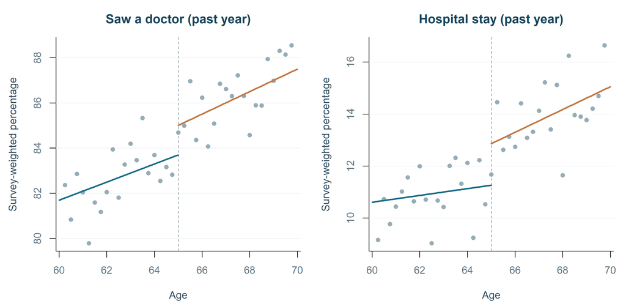

Healthcare use around age 65. Points are survey-weighted quarter-age means; lines are local linear fits within five years of 65.

Each point is the share of respondents in one quarter-year age cell who saw a doctor (left) or had a hospital stay (right) in the past year. The blue line is fitted to ages below 65 and the orange line to ages 65 and above. The vertical gap between the lines at 65 is the estimated discontinuity.

# 3 Main estimates

| Specification | Jump (pp) | 95% CI (pp) | p-value | Rate below cutoff | Relative change | Holm p-value | N | N left | N right |
| --- | --- | --- | --- | --- | --- | --- | --- | --- | --- |
| Saw a doctor (past year): Main: +/-5 years | 1.31 | [-0.42, 3.04] | 0.1379 | 83.7% | 1.6% | 0.1379 | 34,972 | 17,231 | 17,741 |
| Hospital stay (past year): Main: +/-5 years | 1.60 | [0.06, 3.14] | 0.0421 | 11.3% | 14.2% | 0.0842 | 35,513 | 17,496 | 18,017 |

The Holm p-values adjust for testing two outcomes. Doctor visits remain the prespecified primary outcome and hospital stays secondary; we do not choose the outcome according to significance.

**Doctor visits.** The estimated age-65 discontinuity in the probability of having seen a doctor is **1.31 percentage points** (95% CI [-0.42, 3.04]; p = 0.138). Just below 65, 83.7% of people saw a doctor, so this is a relative change of 1.6%. The estimate is positive but imprecise: the confidence interval includes zero. This does not establish a zero effect.

**Hospital stays.** The probability of an overnight hospital stay changes by **1.60 pp** (95% CI [0.06, 3.14]; p = 0.0421), against 11.3% just below 65, a relative change of 14.2%. The jump is significant on its own but not after the Holm adjustment for two outcomes (p = 0.0842). We read it as suggestive of a small increase.

# 4 Robustness of the estimates

These checks show sensitivity to bandwidth, functional form, controls, weighting and sample exclusions. Stability is useful evidence but does not establish a causal interpretation. The checks are correlated, because they reuse the same respondents.

## 4.1 Bandwidth

| Specification | Jump (pp) | 95% CI (pp) | p-value | Rate below cutoff | Relative change | N | N left | N right |
| --- | --- | --- | --- | --- | --- | --- | --- | --- |
| Saw a doctor (past year): Main: +/-5 years | 1.31 | [-0.42, 3.04] | 0.1379 | 83.7% | 1.6% | 34,972 | 17,231 | 17,741 |
| Saw a doctor (past year): +/-3 years | 2.08 | [-0.18, 4.33] | 0.0710 | 82.9% | 2.5% | 20,726 | 9,913 | 10,813 |
| Saw a doctor (past year): +/-4 years | 1.64 | [-0.30, 3.58] | 0.0978 | 83.4% | 2.0% | 27,807 | 13,520 | 14,287 |
| Saw a doctor (past year): +/-6 years | 1.17 | [-0.40, 2.75] | 0.1433 | 83.7% | 1.4% | 42,124 | 20,937 | 21,187 |
| Saw a doctor (past year): +/-7 years | 1.15 | [-0.30, 2.61] | 0.1202 | 83.7% | 1.4% | 49,016 | 24,624 | 24,392 |
| Hospital stay (past year): Main: +/-5 years | 1.60 | [0.06, 3.14] | 0.0421 | 11.3% | 14.2% | 35,513 | 17,496 | 18,017 |
| Hospital stay (past year): +/-3 years | 1.55 | [-0.43, 3.53] | 0.1258 | 11.1% | 13.9% | 21,057 | 10,070 | 10,987 |
| Hospital stay (past year): +/-4 years | 1.62 | [-0.10, 3.34] | 0.0651 | 11.2% | 14.5% | 28,243 | 13,734 | 14,509 |
| Hospital stay (past year): +/-6 years | 1.43 | [0.02, 2.83] | 0.0467 | 11.4% | 12.5% | 42,783 | 21,277 | 21,506 |
| Hospital stay (past year): +/-7 years | 1.39 | [0.09, 2.70] | 0.0368 | 11.5% | 12.0% | 49,794 | 25,051 | 24,743 |

Narrow windows compare people closer to 65 but use fewer observations, so they are noisier. Wide windows are more precise but rely more on the straight-line approximation. No bandwidth is chosen because it gives a significant estimate.

## 4.2 Functional form

| Specification | Jump (pp) | 95% CI (pp) | p-value | Rate below cutoff | Relative change | N | N left | N right |
| --- | --- | --- | --- | --- | --- | --- | --- | --- |
| Saw a doctor (past year): Main: +/-5 years | 1.31 | [-0.42, 3.04] | 0.1379 | 83.7% | 1.6% | 34,972 | 17,231 | 17,741 |
| Saw a doctor (past year): Local quadratic, +/-5 years | 2.42 | [-0.16, 4.99] | 0.0660 | 82.7% | 2.9% | 34,972 | 17,231 | 17,741 |
| Hospital stay (past year): Main: +/-5 years | 1.60 | [0.06, 3.14] | 0.0421 | 11.3% | 14.2% | 35,513 | 17,496 | 18,017 |
| Hospital stay (past year): Local quadratic, +/-5 years | 1.75 | [-0.50, 4.00] | 0.1278 | 10.9% | 16.0% | 35,513 | 17,496 | 18,017 |

A straight line on each side could mistake curvature in the age profile for a jump. A local quadratic allows for curvature, at the cost of precision with so few distinct age values.

## 4.3 Covariate adjustment

Covariate adjustment checks sensitivity to sex, race/ethnicity, education and region. Education is missing for some respondents, so both rows use the same reduced sample; their difference reflects adjustment rather than sample composition. Small changes are consistent with stability, but do not establish balance or repair a discontinuous confounder.

| Specification | Jump (pp) | 95% CI (pp) | p-value | Rate below cutoff | Relative change | N | N left | N right |
| --- | --- | --- | --- | --- | --- | --- | --- | --- |
| Saw a doctor (past year): No covariates, covariate sample | 1.40 | [-0.35, 3.14] | 0.1175 | 83.6% | 1.7% | 34,468 | 16,988 | 17,480 |
| Saw a doctor (past year): With covariates, same sample | 1.42 | [-0.33, 3.16] | 0.1110 | 83.6% | 1.7% | 34,468 | 16,988 | 17,480 |
| Hospital stay (past year): No covariates, covariate sample | 1.55 | [-0.01, 3.10] | 0.0517 | 11.3% | 13.7% | 34,920 | 17,201 | 17,719 |
| Hospital stay (past year): With covariates, same sample | 1.46 | [-0.09, 3.01] | 0.0654 | 11.3% | 12.9% | 34,920 | 17,201 | 17,719 |

## 4.4 Donut RD

| Specification | Jump (pp) | 95% CI (pp) | p-value | Rate below cutoff | Relative change | N | N left | N right |
| --- | --- | --- | --- | --- | --- | --- | --- | --- |
| Saw a doctor (past year): Main: +/-5 years | 1.31 | [-0.42, 3.04] | 0.1379 | 83.7% | 1.6% | 34,972 | 17,231 | 17,741 |
| Saw a doctor (past year): Donut: drop 65.00 | 1.43 | [-0.39, 3.24] | 0.1242 | 83.7% | 1.7% | 34,071 | 17,231 | 16,840 |
| Saw a doctor (past year): Donut: drop 64.75-65.25 | 1.20 | [-0.85, 3.24] | 0.2513 | 84.0% | 1.4% | 32,166 | 16,284 | 15,882 |
| Hospital stay (past year): Main: +/-5 years | 1.60 | [0.06, 3.14] | 0.0421 | 11.3% | 14.2% | 35,513 | 17,496 | 18,017 |
| Hospital stay (past year): Donut: drop 65.00 | 2.02 | [0.36, 3.68] | 0.0168 | 11.3% | 18.0% | 34,590 | 17,496 | 17,094 |
| Hospital stay (past year): Donut: drop 64.75-65.25 | 1.23 | [-0.62, 3.08] | 0.1936 | 11.6% | 10.6% | 32,654 | 16,532 | 16,122 |

- **Drop 65.00.** The quarter-age measure may mix actual eligibility states around the birthday. Dropping this cell checks sensitivity to that coding; the direction of the resulting change is not predetermined.
- **Drop 64.75–65.25.** If people postpone care until they are covered, use dips just before 65 and rebounds just after, which would inflate the jump. Dropping these cells checks sensitivity to local timing and anticipation but does not eliminate either concern. The nearest retained cells are 64.50 and 65.50, so the fit extrapolates across a one-year gap.

## 4.5 Excluding the first year after eligibility

Both outcomes refer to the past 12 months. Respondents just above 65 report use that partly occurred before eligibility, so the age-65 discontinuity does not measure a full year of post-eligibility use. Dropping ages 65.00–65.75 leaves the right-hand fit starting at recorded age 66. Its prediction at 65 is an extrapolation, not a directly observed full-year effect, and attenuation of the main estimate is not guaranteed.

| Specification | Jump (pp) | 95% CI (pp) | p-value | Rate below cutoff | Relative change | N | N left | N right |
| --- | --- | --- | --- | --- | --- | --- | --- | --- |
| Saw a doctor (past year): Main: +/-5 years | 1.31 | [-0.42, 3.04] | 0.1379 | 83.7% | 1.6% | 34,972 | 17,231 | 17,741 |
| Saw a doctor (past year): Exclude ages 65.00-65.75 | 1.16 | [-1.08, 3.39] | 0.3106 | 83.7% | 1.4% | 31,335 | 17,231 | 14,104 |
| Hospital stay (past year): Main: +/-5 years | 1.60 | [0.06, 3.14] | 0.0421 | 11.3% | 14.2% | 35,513 | 17,496 | 18,017 |
| Hospital stay (past year): Exclude ages 65.00-65.75 | 1.80 | [-0.25, 3.86] | 0.0855 | 11.3% | 16.0% | 31,813 | 17,496 | 14,317 |

The extrapolated jump is 1.16 pp for doctor visits (95% CI [-1.08, 3.39]) and 1.80 pp for hospital stays (95% CI [-0.25, 3.86]). Differences from the main specification may reflect exposure timing, curvature or extrapolation error.

## 4.6 Survey weights, year effects and 1993

| Specification | Jump (pp) | 95% CI (pp) | p-value | Rate below cutoff | Relative change | N | N left | N right |
| --- | --- | --- | --- | --- | --- | --- | --- | --- |
| Saw a doctor (past year): Main: +/-5 years | 1.31 | [-0.42, 3.04] | 0.1379 | 83.7% | 1.6% | 34,972 | 17,231 | 17,741 |
| Saw a doctor (past year): No survey weights (kernel only) | 1.35 | [-0.32, 3.02] | 0.1140 | 83.4% | 1.6% | 34,972 | 17,231 | 17,741 |
| Saw a doctor (past year): No year fixed effects | 1.32 | [-0.41, 3.05] | 0.1352 | 83.7% | 1.6% | 34,972 | 17,231 | 17,741 |
| Saw a doctor (past year): Exclude 1993 (half-year sample) | 1.27 | [-0.58, 3.12] | 0.1772 | 84.0% | 1.5% | 30,225 | 14,940 | 15,285 |
| Hospital stay (past year): Main: +/-5 years | 1.60 | [0.06, 3.14] | 0.0421 | 11.3% | 14.2% | 35,513 | 17,496 | 18,017 |
| Hospital stay (past year): No survey weights (kernel only) | 1.38 | [-0.07, 2.84] | 0.0628 | 11.4% | 12.1% | 35,513 | 17,496 | 18,017 |
| Hospital stay (past year): No year fixed effects | 1.60 | [0.06, 3.14] | 0.0416 | 11.3% | 14.2% | 35,513 | 17,496 | 18,017 |
| Hospital stay (past year): Exclude 1993 (half-year sample) | 1.91 | [0.24, 3.58] | 0.0251 | 11.3% | 16.9% | 30,716 | 15,181 | 15,535 |

- **No survey weights.** Keeping only the triangular kernel shows whether the survey weights drive the result.
- **No year fixed effects.** The main specification includes year effects to absorb differences in average use across survey years. Dropping them shows whether this choice matters.
- **Exclude 1993.** The 1993 health insurance supplement was only fielded in the second half of the year, so 1993 is a half-year sample. Dropping it checks that this partial year does not drive the pooled estimate.

## 4.7 Link to the fuzzy RD

| Specification | Jump (pp) | 95% CI (pp) | p-value | Rate below cutoff | Relative change | N | N left | N right |
| --- | --- | --- | --- | --- | --- | --- | --- | --- |
| Saw a doctor (past year): Main: +/-5 years | 1.31 | [-0.42, 3.04] | 0.1379 | 83.7% | 1.6% | 34,972 | 17,231 | 17,741 |
| Saw a doctor (past year): Medicare observed (fuzzy RD sample) | 1.66 | [-0.13, 3.46] | 0.0693 | 83.5% | 2.0% | 32,709 | 16,027 | 16,682 |
| Hospital stay (past year): Main: +/-5 years | 1.60 | [0.06, 3.14] | 0.0421 | 11.3% | 14.2% | 35,513 | 17,496 | 18,017 |
| Hospital stay (past year): Medicare observed (fuzzy RD sample) | 1.68 | [0.09, 3.27] | 0.0387 | 11.1% | 15.1% | 33,113 | 16,218 | 16,895 |

The fuzzy RD requires an observed Medicare answer, so its sample is smaller. The jump on that sample is the numerator of the fuzzy ratio. Dividing the main estimate, from the larger sample, by a Medicare jump from the smaller sample would mix two different groups of people.

## 4.8 Placebo cutoffs

If the method picks up noise or curvature, it would find “jumps” at ages where nothing changes. Each placebo uses a two-year window and data from one side of 65 only, so the real jump cannot leak in: cutoffs at 63 and 64 use ages up to 64.75; cutoffs at 66 and 67 use ages from 65.25. The Holm p-values adjust for all eight placebo tests.

| Specification | Jump (pp) | 95% CI (pp) | p-value | Rate below cutoff | Relative change | Holm p-value | N | N left | N right |
| --- | --- | --- | --- | --- | --- | --- | --- | --- | --- |
| Saw a doctor (past year): Placebo at 63 | 0.74 | [-2.20, 3.67] | 0.624 | 83.6% | 0.9% | 1 | 13,520 | 6,346 | 7,174 |
| Saw a doctor (past year): Placebo at 64 | -0.52 | [-3.64, 2.61] | 0.746 | 84.0% | -0.6% | 1 | 9,913 | 6,309 | 3,604 |
| Saw a doctor (past year): Placebo at 66 | 0.57 | [-3.55, 4.68] | 0.788 | 84.7% | 0.7% | 1 | 9,912 | 2,736 | 7,176 |
| Saw a doctor (past year): Placebo at 67 | 0.57 | [-2.08, 3.22] | 0.673 | 86.0% | 0.7% | 1 | 13,386 | 6,370 | 7,016 |
| Hospital stay (past year): Placebo at 63 | 1.55 | [-0.82, 3.91] | 0.199 | 9.9% | 15.7% | 1 | 13,734 | 6,441 | 7,293 |
| Hospital stay (past year): Placebo at 64 | -0.94 | [-3.62, 1.75] | 0.494 | 12.3% | -7.6% | 1 | 10,070 | 6,407 | 3,663 |
| Hospital stay (past year): Placebo at 66 | 0.95 | [-3.06, 4.96] | 0.643 | 12.2% | 7.8% | 1 | 10,064 | 2,777 | 7,287 |
| Hospital stay (past year): Placebo at 67 | 0.99 | [-1.68, 3.65] | 0.469 | 13.4% | 7.4% | 1 | 13,586 | 6,470 | 7,116 |

No placebo cutoff shows a significant jump for either outcome, before or after adjustment.

Placebo results need not be zero if there is anticipation, another age-related change, or misspecification of the local age trend. At 64 and 66, the windows are asymmetric because observations are restricted to one side of 65. A placebo cannot test whether a separate policy also changes at the real cutoff.

## 4.9 All specifications

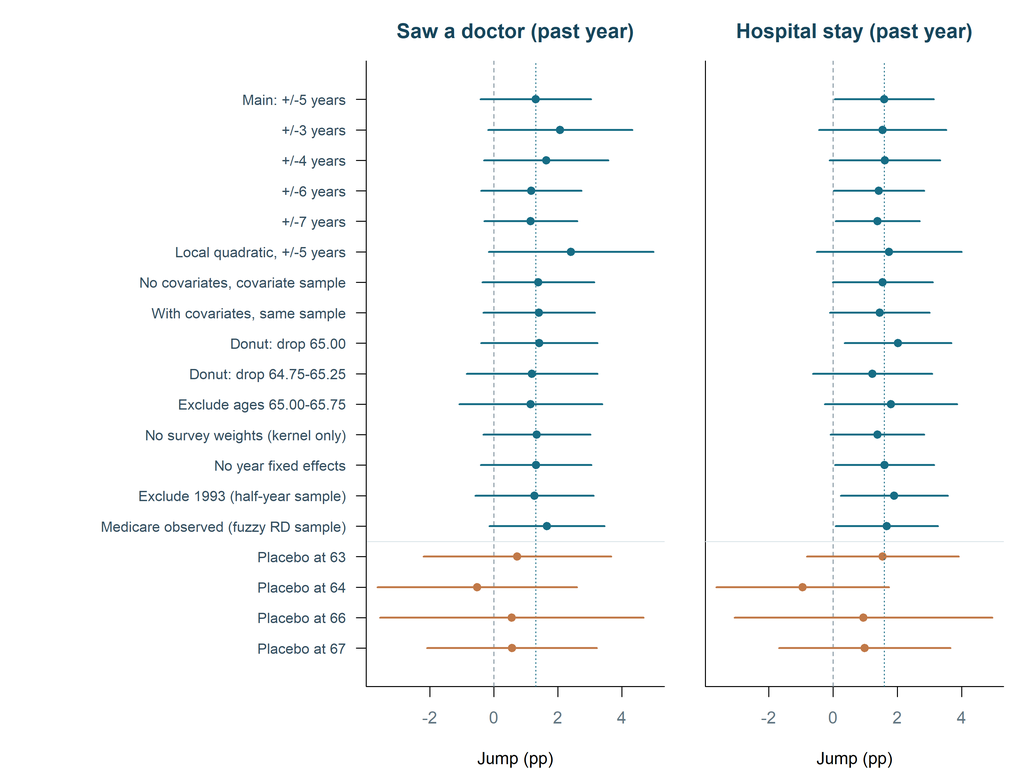

Every estimate with its 95% confidence interval. Teal: estimates of the jump at 65. Orange: placebo cutoffs, where the true jump should be zero. The dotted line marks the main estimate.

The table below lists every estimate in the figure. Each cell gives the jump in percentage points with its 95% confidence interval. Holm p-values are shown only where a family of tests is adjusted: the two main outcomes, and the eight placebo tests.

| Check | Specification | Doctor: jump (pp) [95% CI] | Doctor: p | Doctor: Holm p | Doctor: N | Hospital: jump (pp) [95% CI] | Hospital: p | Hospital: Holm p | Hospital: N |
| --- | --- | --- | --- | --- | --- | --- | --- | --- | --- |
| **Main** | Main: +/-5 years | 1.31 [-0.42, 3.04] | 0.138 | 0.138 | 34,972 | 1.60 [0.06, 3.14] | 0.042 | 0.084 | 35,513 |
| **Bandwidth** | +/-3 years | 2.08 [-0.18, 4.33] | 0.071 | – | 20,726 | 1.55 [-0.43, 3.53] | 0.126 | – | 21,057 |
|  | +/-4 years | 1.64 [-0.30, 3.58] | 0.098 | – | 27,807 | 1.62 [-0.10, 3.34] | 0.065 | – | 28,243 |
|  | +/-6 years | 1.17 [-0.40, 2.75] | 0.143 | – | 42,124 | 1.43 [0.02, 2.83] | 0.047 | – | 42,783 |
|  | +/-7 years | 1.15 [-0.30, 2.61] | 0.120 | – | 49,016 | 1.39 [0.09, 2.70] | 0.037 | – | 49,794 |
| **Functional form** | Local quadratic, +/-5 years | 2.42 [-0.16, 4.99] | 0.066 | – | 34,972 | 1.75 [-0.50, 4.00] | 0.128 | – | 35,513 |
| **Covariates** | No covariates, covariate sample | 1.40 [-0.35, 3.14] | 0.117 | – | 34,468 | 1.55 [-0.01, 3.10] | 0.052 | – | 34,920 |
|  | With covariates, same sample | 1.42 [-0.33, 3.16] | 0.111 | – | 34,468 | 1.46 [-0.09, 3.01] | 0.065 | – | 34,920 |
| **Donut** | Donut: drop 65.00 | 1.43 [-0.39, 3.24] | 0.124 | – | 34,071 | 2.02 [0.36, 3.68] | 0.017 | – | 34,590 |
|  | Donut: drop 64.75-65.25 | 1.20 [-0.85, 3.24] | 0.251 | – | 32,166 | 1.23 [-0.62, 3.08] | 0.194 | – | 32,654 |
| **Exposure timing** | Exclude ages 65.00-65.75 | 1.16 [-1.08, 3.39] | 0.311 | – | 31,335 | 1.80 [-0.25, 3.86] | 0.086 | – | 31,813 |
| **Weights and years** | No survey weights (kernel only) | 1.35 [-0.32, 3.02] | 0.114 | – | 34,972 | 1.38 [-0.07, 2.84] | 0.063 | – | 35,513 |
|  | No year fixed effects | 1.32 [-0.41, 3.05] | 0.135 | – | 34,972 | 1.60 [0.06, 3.14] | 0.042 | – | 35,513 |
|  | Exclude 1993 (half-year sample) | 1.27 [-0.58, 3.12] | 0.177 | – | 30,225 | 1.91 [0.24, 3.58] | 0.025 | – | 30,716 |
| **Fuzzy RD sample** | Medicare observed (fuzzy RD sample) | 1.66 [-0.13, 3.46] | 0.069 | – | 32,709 | 1.68 [0.09, 3.27] | 0.039 | – | 33,113 |
| **Placebo cutoffs** | Placebo at 63 | 0.74 [-2.20, 3.67] | 0.624 | 1.000 | 13,520 | 1.55 [-0.82, 3.91] | 0.199 | 1.000 | 13,734 |
|  | Placebo at 64 | -0.52 [-3.64, 2.61] | 0.746 | 1.000 | 9,913 | -0.94 [-3.62, 1.75] | 0.494 | 1.000 | 10,070 |
|  | Placebo at 66 | 0.57 [-3.55, 4.68] | 0.788 | 1.000 | 9,912 | 0.95 [-3.06, 4.96] | 0.643 | 1.000 | 10,064 |
|  | Placebo at 67 | 0.57 [-2.08, 3.22] | 0.673 | 1.000 | 13,386 | 0.99 [-1.68, 3.65] | 0.469 | 1.000 | 13,586 |

# 5 Subgroup comparisons

## 5.1 The prediction

For doctor visits, we explore whether larger net gains in any insurance accompany larger utilisation increases. This pattern would be consistent with improved access among previously uninsured respondents, but is not a necessary implication of an insurance effect. For hospital stays, previously insured respondents may also respond to more generous coverage or changes in procedure costs. We therefore do not impose the doctor-visit ordering on hospital stays. Employment comparisons are indirect diagnostics and cannot by themselves separate retirement from insurance channels.

The four groups combine race/ethnicity and observed education. Respondents with missing education remain in the pooled estimates but are excluded from these subgroup comparisons. The comparisons are exploratory, not preregistered causal tests.

## 5.2 Matched samples

For each outcome and group, the sample keeps respondents with the outcome, any coverage, Medicare and employment all observed. The outcome, coverage, Medicare and employment jumps for a group therefore use exactly the same people, and the coverage, Medicare and employment jumps match those in the identification report. Rates before 65 are weighted means for ages 63 to under 65.

## 5.3 Outcome jumps by group

| Outcome | Group | N left / right | Outcome jump (pp) | Coverage gain (pp) | Medicare jump (pp) | Employment jump (pp) | Uninsured before 65 |
| --- | --- | --- | --- | --- | --- | --- | --- |
| Saw a doctor (past year) | White non-Hispanic, high education | 9,364 / 9,432 | 0.41 [-1.88, 2.71] | 5.1 [3.8, 6.4] | 64.0 [61.6, 66.5] | 0.7 [-2.3, 3.8] | 6.9% |
| Saw a doctor (past year) | White non-Hispanic, low education | 2,863 / 3,657 | 3.66 [-0.52, 7.84] | 9.5 [6.6, 12.4] | 57.9 [53.3, 62.4] | 1.9 [-2.6, 6.3] | 13.6% |
| Saw a doctor (past year) | Other race/ethnicity, high education | 1,857 / 1,523 | 2.04 [-3.79, 7.88] | 8.3 [3.9, 12.8] | 58.4 [52.2, 64.7] | -4.4 [-12.0, 3.1] | 14.5% |
| Saw a doctor (past year) | Other race/ethnicity, low education | 1,808 / 1,952 | 4.18 [-1.48, 9.85] | 17.7 [11.8, 23.5] | 44.7 [37.9, 51.6] | 0.2 [-5.7, 6.1] | 28.1% |
| Hospital stay (past year) | White non-Hispanic, high education | 9,447 / 9,535 | 0.85 [-1.18, 2.88] | 5.1 [3.8, 6.3] | 63.9 [61.5, 66.4] | 0.6 [-2.4, 3.6] | 6.8% |
| Hospital stay (past year) | White non-Hispanic, low education | 2,896 / 3,697 | 3.61 [-0.12, 7.34] | 9.8 [6.9, 12.7] | 58.1 [53.6, 62.6] | 1.7 [-2.7, 6.1] | 13.7% |
| Hospital stay (past year) | Other race/ethnicity, high education | 1,886 / 1,552 | 2.01 [-2.97, 6.99] | 8.8 [4.3, 13.2] | 58.5 [52.3, 64.7] | -3.6 [-11.1, 3.9] | 14.8% |
| Hospital stay (past year) | Other race/ethnicity, low education | 1,831 / 1,984 | 1.31 [-3.65, 6.27] | 16.7 [10.6, 22.8] | 44.3 [37.4, 51.2] | 0.6 [-5.5, 6.6] | 28.1% |

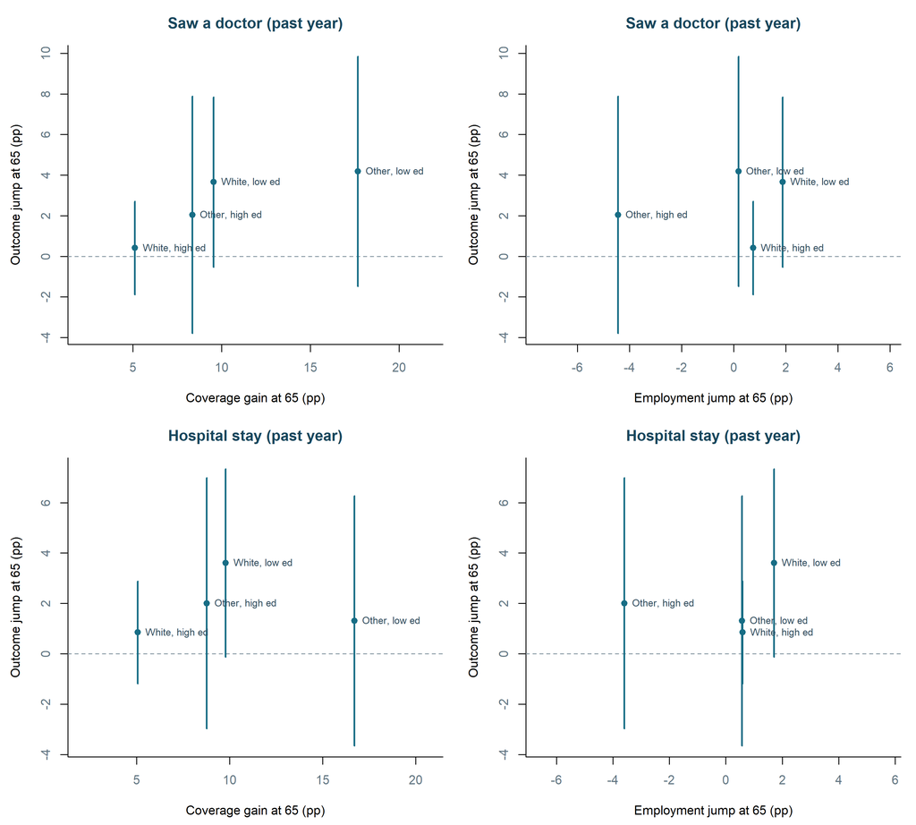

Outcome jumps by group, with 95% confidence intervals, against the coverage gain at 65 (left) and the employment jump at 65 (right). A positive doctor-visit relationship is consistent with the access hypothesis; no such ordering is required for hospital stays.

## 5.4 Does the pattern follow the prediction?

The rank correlations describe how closely the ordering of outcome jumps matches each measure, from -1 (reversed) to 1 (identical). With four groups they are descriptive, not tests. The exploratory contrast compares the groups with the largest and smallest estimated coverage gains. It is an access-channel comparison for doctor visits and a descriptive contrast for hospital stays. Its standard error treats the disjoint groups as independent.

| Outcome | Rank corr. with coverage gain | Rank corr. with Medicare jump | Rank corr. with employment drop | Largest minus smallest coverage-gain group (pp) | p-value |
| --- | --- | --- | --- | --- | --- |
| Saw a doctor (past year) | 1.00 | -1.00 | 0.00 | 3.77 [-2.34, 9.88] | 0.227 |
| Hospital stay (past year) | 0.40 | -0.40 | -0.20 | 0.46 [-4.90, 5.82] | 0.867 |

**Doctor visits.** The rank correlation with net coverage gains is **1.00**, compared with 0.00 for employment declines. The contrast between the groups with the largest and smallest coverage gains is 3.77 pp (95% CI [-2.34, 9.88]; p = 0.227). Alignment with coverage gains would be consistent with improved access, not proof of a specific mechanism.

**Hospital stays.** The corresponding correlations are 0.40 with coverage gains and -0.20 with employment declines. The same pairwise group contrast is 0.46 pp (95% CI [-4.90, 5.82]; p = 0.867). This contrast is descriptive: hospital responses need not follow coverage gains because previously insured people can benefit from changes in insurance generosity.

Four estimated group points cannot distinguish insurance, retirement and other heterogeneous responses. These correlations omit uncertainty in both axes; nonrejection of group employment jumps does not establish zero retirement effects.

# 6 Conclusion

**Doctor visits.** The estimated age-65 jump is **1.31 pp** (95% CI [-0.42, 3.04]; p = 0.138), relative to a fitted rate of 83.7% below 65. The estimate is positive but imprecise, and not statistically significant at 5%.

**Hospital stays.** The estimated jump is **1.60 pp** (95% CI [0.06, 3.14]; p = 0.0421), relative to 11.3% below 65. It is significant on its own but not after the Holm adjustment for two outcomes (p = 0.0842), so it is suggestive of a small increase.

**Robustness.** Doctor-visit estimates have the main estimate’s sign in 14 of 14 alternative specifications, and 0 are significant at 5%. Hospital estimates have the main sign in 14 of 14, and 6 are significant. No placebo cutoff rejects after adjustment. These correlated checks are sensitivity summaries, not independent confirmations.

**Interpretation.** Under continuity, a well-defined eligibility policy and the maintained interference assumptions, these discontinuities are local eligibility ITTs. We do not detect a statistically significant employment discontinuity at 65 under the main specification. Subgroup comparisons provide exploratory evidence about insurance and retirement channels, but do not identify which dominates. Hospital responses need not follow newly gained coverage, and independent pension, income and retirement effects remain possible.

## 6.1 Limitations

- **Approximate inference.** Age takes few distinct values near 65, so HC1 confidence intervals do not fully account for misfit of the age trend within cells. Clustering by age cell is not used, because clustering by the running variable does not generally protect against trend misspecification (Kolesár and Rothe, 2018). HC1 also does not reflect the full NHIS survey design.
- **Recall window and extrapolation.** Past-year use includes pre-eligibility time near 65. Excluding the first year above the threshold requires extrapolation and does not identify a full-year effect.
- **Local effect.** The estimate applies to people around 65 in 1992–1996, not to all ages or later years.
- **Eligibility, not enrolment.** The fuzzy RD needs additional assumptions to identify an enrolment effect for people who take up Medicare at 65.

## 6.2 References

Card, D., Dobkin, C. and Maestas, N. (2008). [The Impact of Nearly Universal Insurance Coverage on Health Care Utilization: Evidence from Medicare](https://pmc.ncbi.nlm.nih.gov/articles/PMC2600774/). *American Economic Review*, 98(5), 2242-2258.

Kolesár, M. and Rothe, C. (2018). Inference in Regression Discontinuity Designs with a Discrete Running Variable. *American Economic Review*, 108(8), 2277-2304.